# Talk Results Companion V3: Strong TV Confounding DGP

Figure and Table Bank — Strong Time-Varying Confounding Parameters

Author

Sara Levintow & Andrew Mertens

Published

March 31, 2026

# 1 Setup

```
proj_root: C:/Users/andre/OneDrive/Documents/hiv_adherence_simulation/simulation V4
```

```
repo_root: C:/Users/andre/OneDrive/Documents/hiv_adherence_simulation
```

# 2 Simulate Data

# 3 Oracle Forgiveness Curves

```
  [saved: fig-oracle]
```

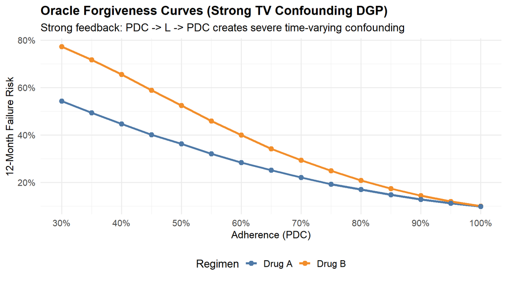

Figure 1: True cumulative failure risk by adherence level and drug under strong TV confounding DGP. Drug A shows greater forgiveness at sub-optimal adherence.

# 4 DAG: Time-Dependent Confounding

```
  [saved: fig-dag]
```

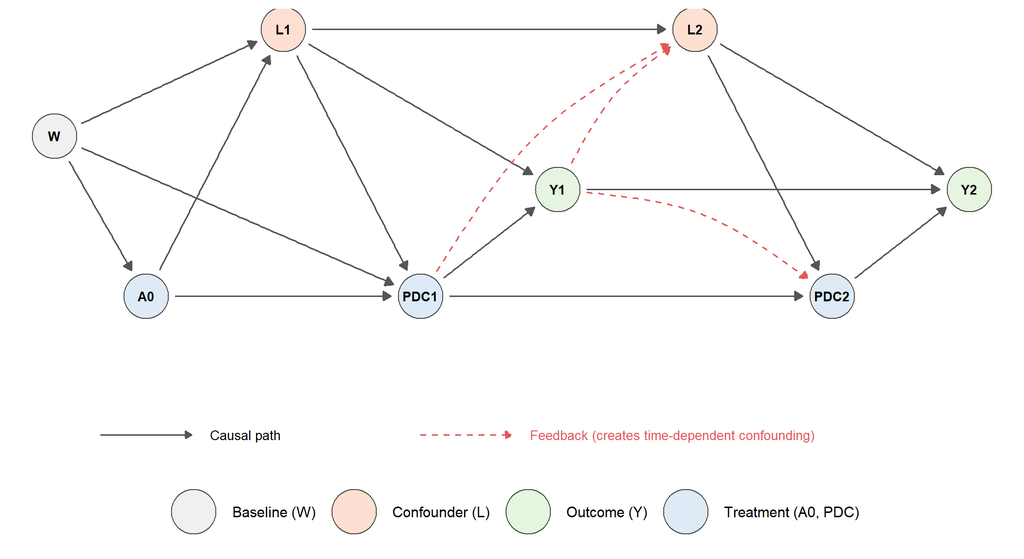

Figure 2: Two-period DAG with time-dependent confounding. Red dashed arrows show feedback from treatment/outcome to future confounders — the structure that breaks standard regression.

## 4.1 Why time-varying confounding breaks standard regression

The following sequence of DAGs illustrates step by step why standard approaches fail when L is both a confounder and a mediator. Each figure highlights specific causal paths.

### 4.1.1 Step 1: The full causal structure (all paths)

All arrows shown equally — this is the data-generating process. PDC (adherence) at each block is affected by health (L), and adherence in turn affects future health — the feedback loop.

```
  [saved: fig-dag-step1]
```

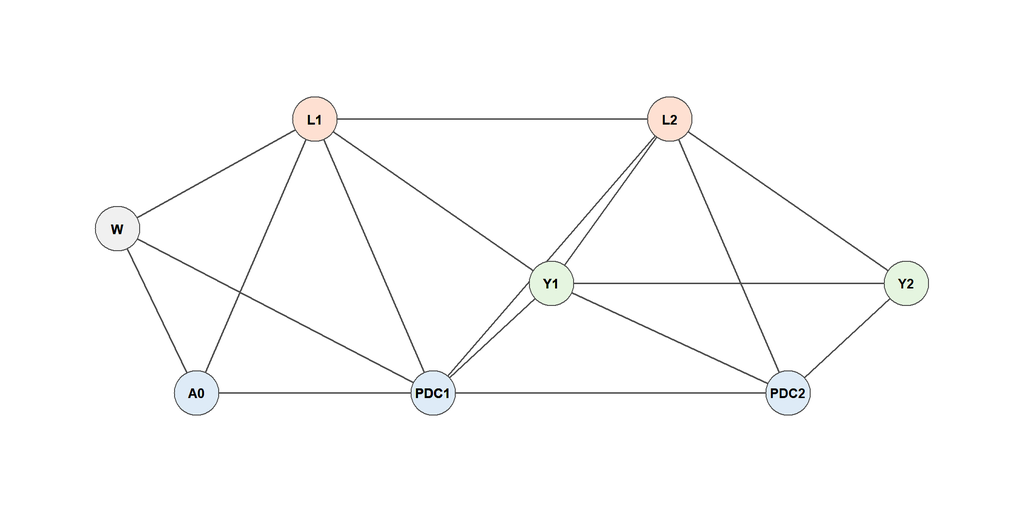

Figure 3: Step 1: Full causal structure. All paths shown — no highlighting.

### 4.1.2 Step 2: The causal effect of interest

We want to estimate the effect of adherence (PDC) on outcome (Y). The direct causal paths from PDC to Y are highlighted.

```
  [saved: fig-dag-step2]
```

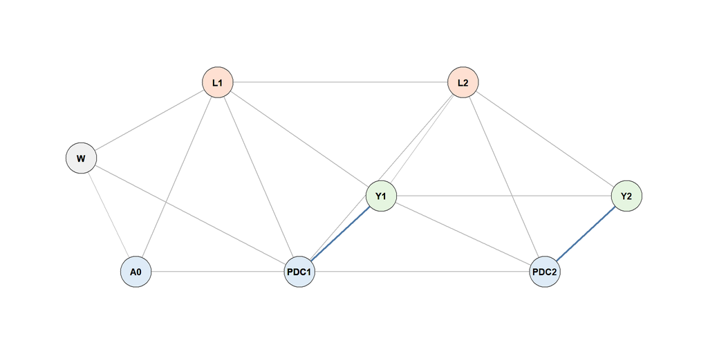

Figure 4: Step 2: Causal paths of interest. PDC -> Y at each period — the effect we want to estimate.

### 4.1.3 Step 3: The confounding problem — L confounds PDC-Y

Health (L) is a common cause of both adherence (PDC) and outcome (Y). Without adjustment, the PDC-Y association is confounded: sicker patients have worse adherence AND worse outcomes.

```
  [saved: fig-dag-step3]
```

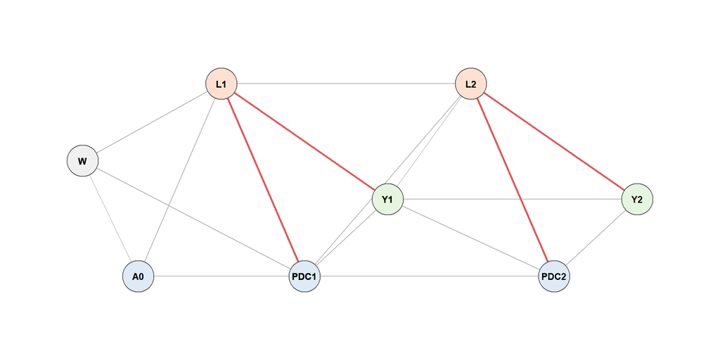

Figure 5: Step 3: The confounding problem. L is a common cause of PDC and Y — the back-door path that biases naive analysis.

### 4.1.4 Step 4: Why adjusting for L2 fails — L2 is also a mediator

Adjusting for L2 blocks the confounding path (L2 → PDC2 → Y2), but it *also* blocks part of the causal effect of PDC1 on Y2 that operates *through* L2. PDC1 affects L2 (worse adherence worsens health), which then affects Y2. By conditioning on L2, we remove this indirect causal effect.

```
  [saved: fig-dag-step4]
```

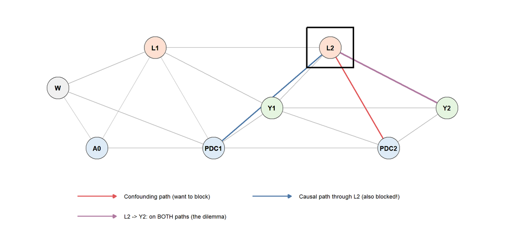

Figure 6: Step 4: Why adjusting for L2 fails. Red = confounding path we want to block. Blue = causal path from PDC1 through L2 to Y2 that is ALSO blocked by conditioning on L2.

### 4.1.5 Step 5: The feedback loop that creates the dilemma

The reason L2 is both a confounder and a mediator is the **feedback loop**: PDC1 → L2 → PDC2. Prior adherence affects future health, which affects future adherence. This is the defining structure of time-dependent confounding — it cannot be solved by any form of standard regression.

```
  [saved: fig-dag-step5]
```

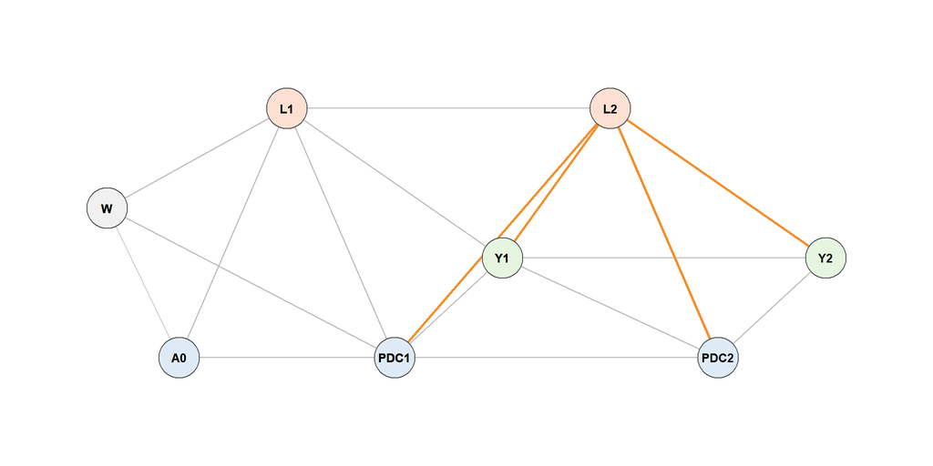

Figure 7: Step 5: The feedback loop. PDC1 -> L2 -> PDC2 is the path that makes L2 both a confounder and a mediator simultaneously.

### 4.1.6 Step 6: How L-TMLE solves it

L-TMLE handles the dilemma by **intervening** on adherence rather than **conditioning** on it. Instead of asking “what is the outcome for people who happened to have high PDC?” (which selects healthier people), it asks “what would the outcome be if we *set* everyone’s PDC to high?” The backward iterative targeting step correctly standardises over the distribution of L under the intervention, removing confounding without blocking the causal pathway.

```
  [saved: fig-dag-step6]
```

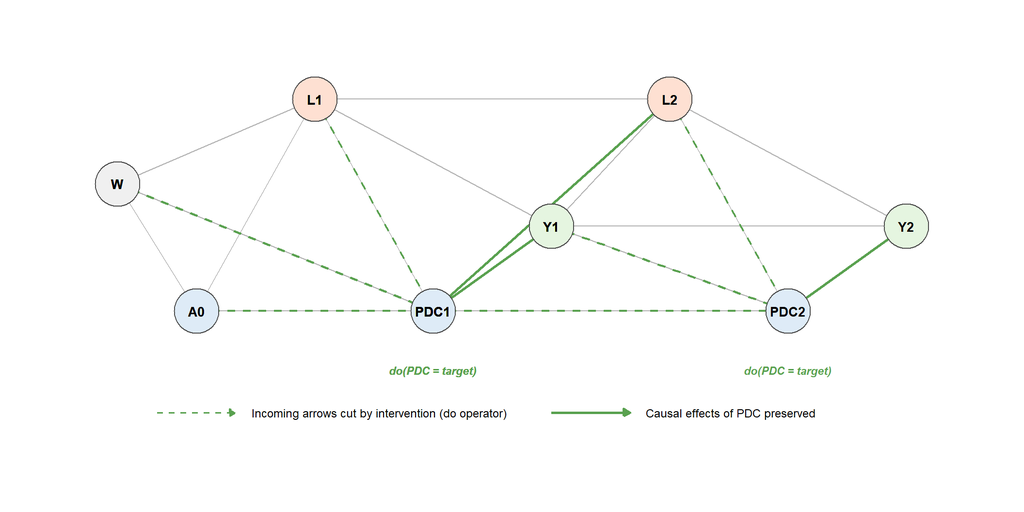

Figure 8: Step 6: L-TMLE solution. Green = intervention nodes (PDC is SET, not conditioned on). The g-model learns the natural treatment mechanism; the Q-model learns the outcome; the targeting step debiases.

# 5 Descriptive Statistics

Table 1: Simulated cohort characteristics (Strong TV confounding DGP, N = 5,000, K = 4 quarters)

| Characteristic | Value |
| --- | --- |
| Sample size | 5,000 |
| Follow-up | 12 months (4 blocks) |
| Block size | 90 days (quarterly) |
| Drug A, n (%) | 2,461 (49.2%) |
| Drug B, n (%) | 2,539 (50.8%) |
| Mean PDC -- Drug A (SD) | 0.620 (0.164) |
| Mean PDC -- Drug B (SD) | 0.718 (0.147) |
| Mean PDC Q1 -- Drug A | 0.668 |
| Mean PDC Q1 -- Drug B | 0.754 |
| Mean PDC Q4 -- Drug A | 0.544 |
| Mean PDC Q4 -- Drug B | 0.662 |
| Cumulative failure, n (%) | 1460 (29.2%) |
| Drug A | 27.1% |
| Drug B | 31.2% |
| PDC < 65% at any block (%) |  |
| Drug A | 77.0% |
| Drug B | 56.0% |

Table 2: Strong TV confounding: weak baseline, strong feedback. This creates a setting where only L-TMLE can properly adjust.

| Process | Parameter | Default | Strong TV |
| --- | --- | --- | --- |
| Baseline confounding | betaW (W -> L) | 0.30 | 0.10 |
|  | alphaW (W -> PDC) | -0.20 | -0.05 |
|  | gammaW (W -> Y) | 0.30 | 0.10 |
| TV feedback loop | betaP (PDC -> L) | 0.80 | 1.50 |
|  | betaLag (L persistence) | 0.35 | 0.50 |
|  | alphaL (L -> PDC) | -0.30 | -0.60 |
|  | gammaL (L -> Y) | 0.50 | 1.00 |
| Drug A adherence | alphaA (Drug A effect) | -0.35 | -0.50 |
|  | Drug A mean PDC vs Drug B | lower | notably lower |
| Failure hazard | gammaP (PDC -> Y) | 2.50 | 2.50 (unchanged) |
|  | gammaAP (Drug A forgiveness) | -1.20 | -1.20 (unchanged) |
|  | gamma0 (baseline hazard) | -3.80 | -3.80 (unchanged) |

# 6 Naive Analysis

Table 3: Naive failure rates vs oracle truth: bias from strong time-dependent confounding

| Drug | Stratum | N | Naive Risk | Oracle | Bias |
| --- | --- | --- | --- | --- | --- |
| Drug A | Low | 1323 | 0.378 | 0.518 | -0.140 |
| Drug A | Mid | 978 | 0.154 | 0.196 | -0.042 |
| Drug A | High | 160 | 0.106 | 0.122 | -0.016 |
| Drug B | Low | 749 | 0.562 | 0.741 | -0.179 |
| Drug B | Mid | 1290 | 0.238 | 0.250 | -0.012 |
| Drug B | High | 500 | 0.128 | 0.134 | -0.006 |

```
  [saved: fig-naive]
```

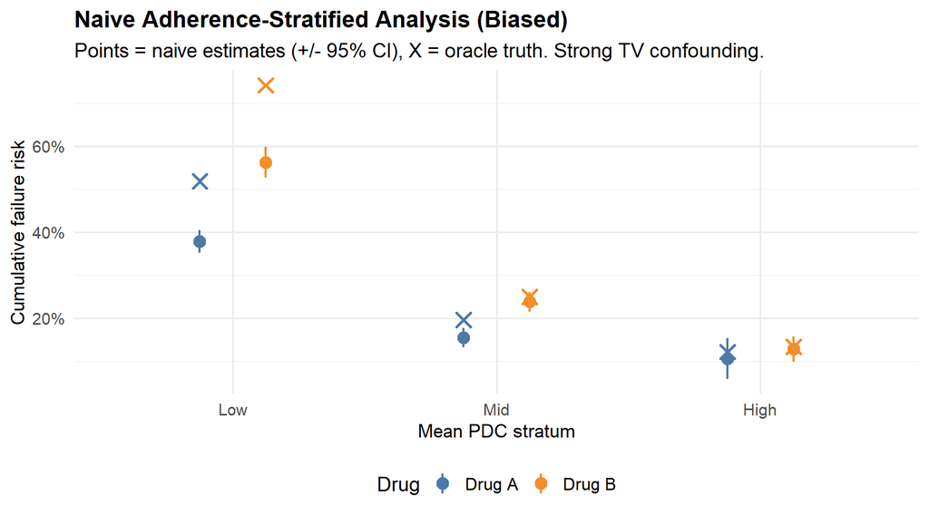

Figure 9: Naive failure rates (points +/- 95% CI) vs oracle truth (X). Strong TV confounding creates large bias, especially in the Low stratum where feedback is strongest.

The naive analysis shows large bias under strong TV confounding, particularly in the Low adherence stratum where the feedback loop (poor PDC -> worse L -> even worse PDC -> higher failure) is most active.

# 7 LTMLE Static Regime Results

## 7.1 Oracle values for category regimes

Oracle risks under static category regimes (strong TV confounding DGP)

| Drug | Category | Oracle (uniform) |
| --- | --- | --- |
| Drug B | high | 0.1308 |
| Drug B | mid | 0.2512 |
| Drug B | low | 0.7418 |
| Drug A | high | 0.1212 |
| Drug A | mid | 0.1939 |
| Drug A | low | 0.5185 |

## 7.2 Fit LTMLE (GLM-based)

Table 4: LTMLE estimates vs oracle (strong TV confounding, GLM nuisance models)

| Drug | Category | LTMLE | SE | Oracle | Bias | Converged |
| --- | --- | --- | --- | --- | --- | --- |
| Drug B | high | 0.1582 | 0.0239 | 0.1308 | 0.0274 | TRUE |
| Drug B | low | 0.6262 | 0.0374 | 0.7418 | -0.1156 | TRUE |
| Drug B | mid | 0.2430 | 0.0249 | 0.2512 | -0.0082 | TRUE |
| Drug A | high | 0.1756 | 0.0676 | 0.1212 | 0.0543 | TRUE |
| Drug A | low | 0.4053 | 0.0217 | 0.5185 | -0.1132 | TRUE |
| Drug A | mid | 0.1751 | 0.0296 | 0.1939 | -0.0188 | TRUE |

## 7.3 Estimated vs oracle forgiveness curves (3-category)

```
  [saved: fig-ltmle-vs-oracle-3cat]
```

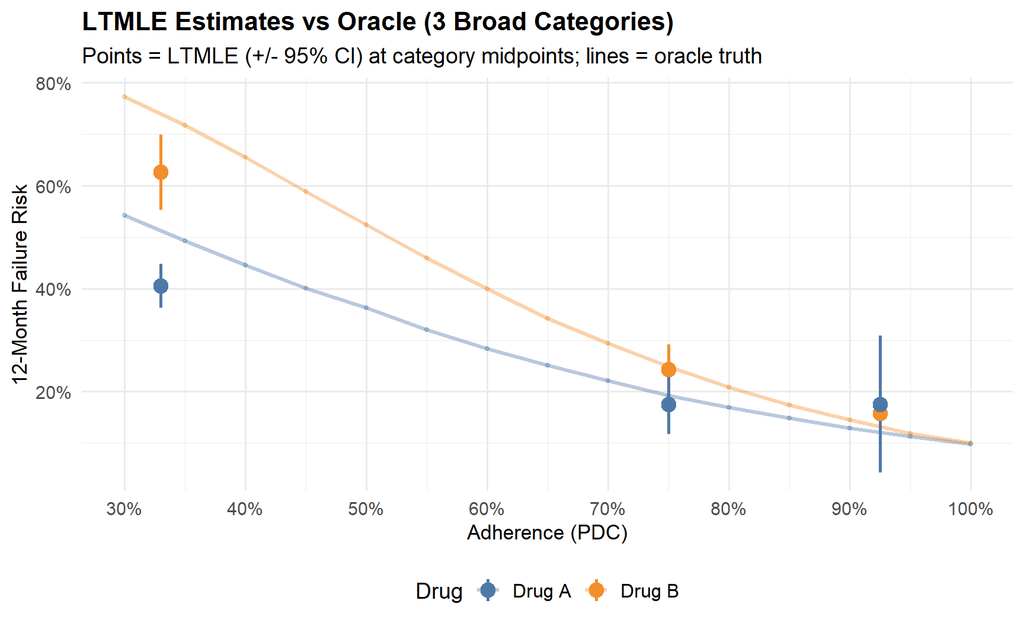

Figure 10: LTMLE estimates (3 broad categories) overlaid on oracle curves.

## 7.4 Estimated vs oracle forgiveness curves (fine grid, 10%-wide sliding bins)

This loads pre-computed results from `12_fine_grid_ltmle.R`: LTMLE estimates for 10%-wide PDC bins sliding every 5% (e.g., [30-40%], [35-45%], …, [90-100%]). Each bin intervenes by drawing PDC uniformly from that range at every block.

```
Fine grid loaded: 13 bins x 2 drugs, 26 converged
Coverage in bins >= 50%: 15/18 (83%)
```

### 7.4.1 Well-supported range (PDC >= 70%)

```
  [saved: fig-ltmle-fine-70plus]
```

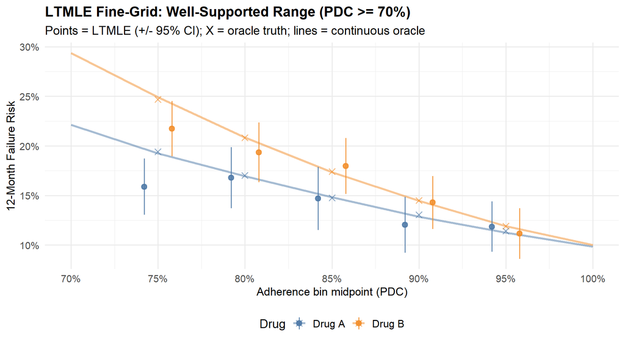

### 7.4.2 Extended range (PDC >= 40%, showing positivity transition)

```
  [saved: fig-ltmle-fine-extended]
```

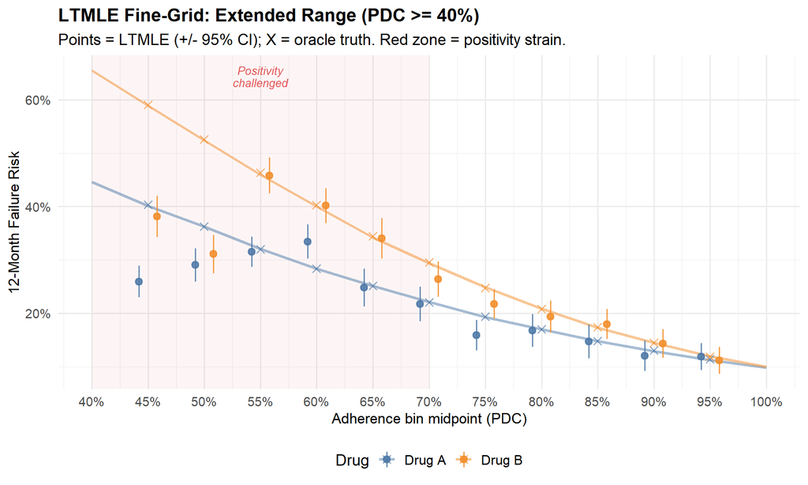

Figure 12: LTMLE fine-grid estimates from 40% PDC upward. The shaded region (< 70%) shows where positivity begins to break down — fewer patients sustain low adherence for all 4 blocks, leading to wider CIs and poorer coverage. This motivates the LMTP shift approach.

# 8 Positivity and Support Diagnostics

## 8.1 PDC distribution by drug and block

```
  [saved: fig-pdc-violin]
```

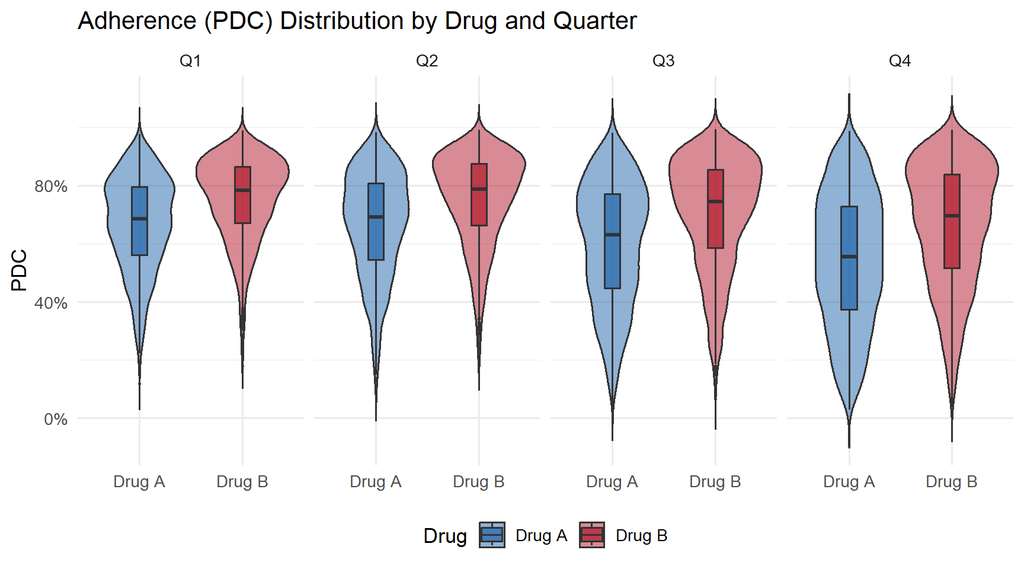

Figure 13: Adherence (PDC) distribution by drug and quarter under strong TV confounding. Drug A has notably lower adherence (alphaA = -0.50).

## 8.2 Support heatmap

```
  [saved: fig-support-heatmap]
```

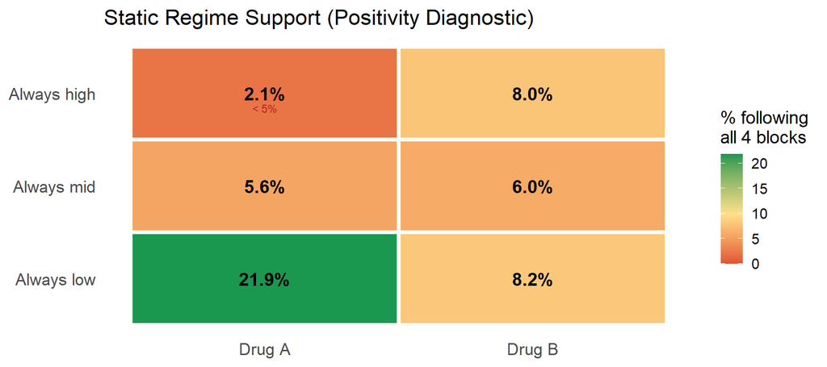

Figure 14: Proportion of subjects naturally following each static regime across all 4 blocks. Low support regimes face positivity problems.

## 8.3 Detailed support diagnostics

Table 5: Effective support diagnostics: per-block category frequencies and full-regime adherence

| Drug | Regime | Block_pcts | N_follow | Pct_follow | Events | Flag |
| --- | --- | --- | --- | --- | --- | --- |
| Drug B | always_high | 29% / 33% / 26% / 23% | 202 | 8.0% | 25 | OK |
| Drug B | always_mid | 49% / 44% / 41% / 35% | 153 | 6.0% | 34 | OK |
| Drug B | always_low | 22% / 23% / 32% / 42% | 209 | 8.2% | 149 | OK |
| Drug A | always_high | 12% / 17% / 12% / 10% | 51 | 2.1% | 7 | SPARSE |
| Drug A | always_mid | 46% / 42% / 35% / 26% | 137 | 5.6% | 15 | OK |
| Drug A | always_low | 41% / 41% / 53% / 64% | 538 | 21.9% | 242 | OK |

# 9 LMTP Results

This section loads pre-computed LMTP results from `13_lmtp_seed_search.R`, which searched for a dataset where the shift and quantile-match estimates are close to the oracle truth.

## 9.1 Load pre-computed LMTP results

```
Loaded LMTP results (seed = 3, N = 5000)
```

## 9.2 Additive PDC shift (+10%)

Table 6: LMTP estimates: natural risk and +10% PDC shift vs oracle (seed = 3)

|  | Drug | Natural | Nat. Oracle | Nat. Bias | +10% Shift | Shift Oracle | Shift Bias |
| --- | --- | --- | --- | --- | --- | --- | --- |
| Drug B | Drug B | 0.3040 | 0.3002 | 0.0038 | 0.1750 | 0.1747 | 0.0003 |
| Drug A | Drug A | 0.3004 | 0.2868 | 0.0136 | 0.1835 | 0.1946 | -0.0111 |

```
  [saved: fig-lmtp-shift]
```

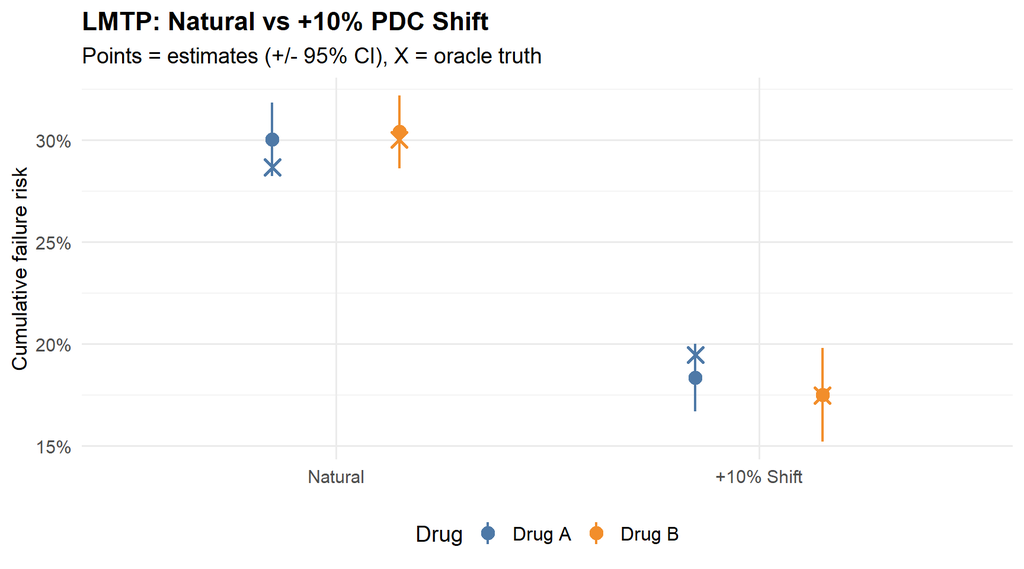

Figure 15: LMTP shift estimates (points +/- 95% CI) vs oracle truth (X). Comparing natural risk to +10% PDC shift.

## 9.3 Shift distribution visualization

```
  [saved: fig-shift-dist]
```

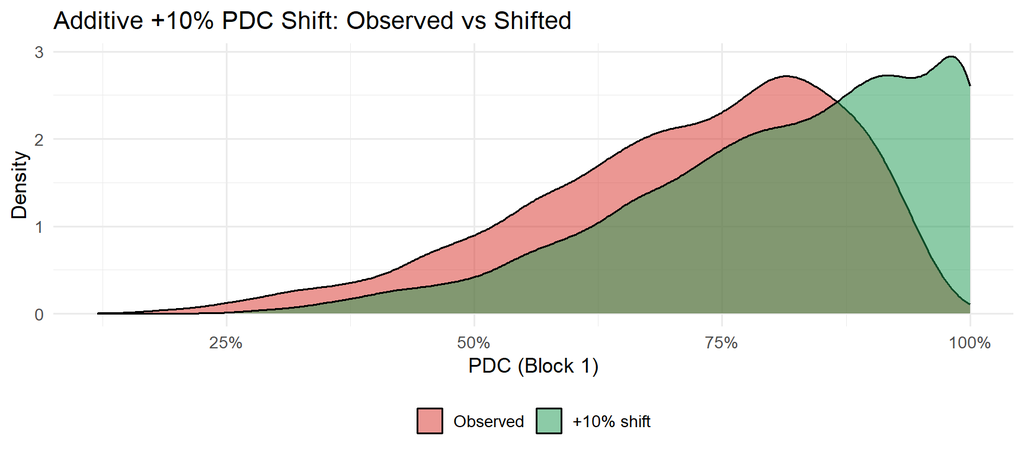

Figure 16: Observed vs +10% shifted PDC distribution. The shift stays within observed support.

## 9.4 Quantile-matched drug comparison

The quantile-matching approach maps one drug’s adherence distribution to the other’s at every block, isolating the pharmacological effect from adherence behaviour differences. If Drug A patients had Drug B’s adherence pattern (or vice versa), how much of the drug effect remains?

Table 7: Quantile-matched drug comparison: isolating pharmacological effect from adherence differences

| Direction | Estimate | Oracle | Bias |
| --- | --- | --- | --- |
| Under Drug B adherence: Drug B | 0.3040 | 0.2968 | 0.0072 |
| Under Drug B adherence: Drug A | 0.1933 | 0.2212 | -0.0279 |
| RD (A - B) under Drug B adherence | -0.1107 | -0.0756 | -0.0351 |
| Under Drug A adherence: Drug A | 0.3008 | 0.2837 | 0.0171 |
| Under Drug A adherence: Drug B | 0.4818 | 0.4039 | 0.0779 |
| RD (A - B) under Drug A adherence | -0.1810 | -0.1202 | -0.0607 |

```
  [saved: fig-matched-forest]
```

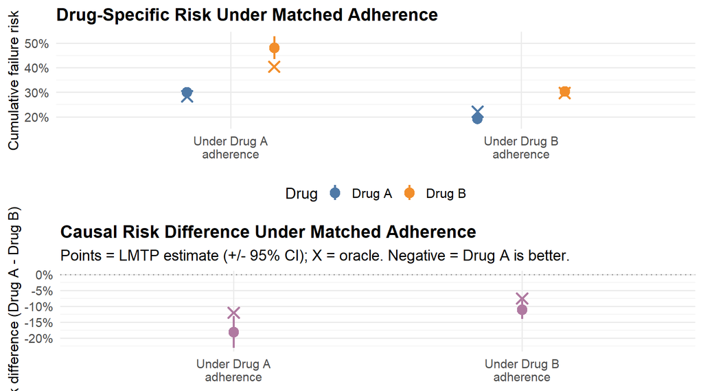

Figure 17: Drug comparison under quantile-matched adherence. Under either drug’s adherence pattern, Drug A has lower failure risk — this is the isolated pharmacological (forgiveness) effect.

```
  [saved: fig-density-quantile]
```

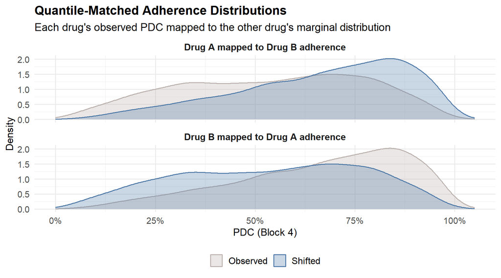

Figure 18: Quantile-matched adherence distributions at the final block. Each drug’s observed PDC mapped to the other drug’s marginal distribution.

# 10 Bias Comparison: Monte Carlo Results

This section loads pre-computed Monte Carlo results from the strong TV confounding scenario. With 4 methods (Naive, Reg(baseline), Reg(baseline+TV), L-TMLE) across 3 strata and 2 drugs, we compare bias performance.

```
Loaded 4800 MC iteration-rows across 200 iterations
```

```
Methods: Naive, Reg (baseline), Reg (baseline + TV), L-TMLE
```

```
Strata: Low, Mid, High
```

Table 8: MC bias comparison across 4 methods under strong TV confounding

|  | Stratum | Drug | Method | Mean Bias | SE(Bias) | Mean &#124;Bias&#124; | N Converged |
| --- | --- | --- | --- | --- | --- | --- | --- |
| 10 | Low | Drug A | Naive | -0.1324 | 0.0012 | 0.1324 | 200 |
| 12 | Low | Drug A | Reg (baseline) | -0.1412 | 0.0012 | 0.1412 | 200 |
| 11 | Low | Drug A | Reg (baseline + TV) | -0.2173 | 0.0012 | 0.2173 | 200 |
| 9 | Low | Drug A | L-TMLE | -0.0998 | 0.0019 | 0.0998 | 200 |
| 14 | Low | Drug B | Naive | -0.2080 | 0.0020 | 0.2080 | 200 |
| 16 | Low | Drug B | Reg (baseline) | -0.2223 | 0.0020 | 0.2223 | 200 |
| 15 | Low | Drug B | Reg (baseline + TV) | -0.3594 | 0.0020 | 0.3594 | 200 |
| 13 | Low | Drug B | L-TMLE | -0.1573 | 0.0034 | 0.1573 | 200 |
| 18 | Mid | Drug A | Naive | -0.0184 | 0.0013 | 0.0213 | 200 |
| 20 | Mid | Drug A | Reg (baseline) | -0.0132 | 0.0013 | 0.0186 | 200 |
| 19 | Mid | Drug A | Reg (baseline + TV) | 0.0608 | 0.0017 | 0.0608 | 200 |
| 17 | Mid | Drug A | L-TMLE | -0.0018 | 0.0026 | 0.0301 | 200 |
| 22 | Mid | Drug B | Naive | -0.0097 | 0.0012 | 0.0152 | 200 |
| 24 | Mid | Drug B | Reg (baseline) | -0.0086 | 0.0012 | 0.0146 | 200 |
| 23 | Mid | Drug B | Reg (baseline + TV) | 0.0179 | 0.0012 | 0.0208 | 200 |
| 21 | Mid | Drug B | L-TMLE | -0.0078 | 0.0022 | 0.0251 | 200 |
| 2 | High | Drug A | Naive | -0.0202 | 0.0020 | 0.0288 | 200 |
| 4 | High | Drug A | Reg (baseline) | -0.0108 | 0.0022 | 0.0271 | 200 |
| 3 | High | Drug A | Reg (baseline + TV) | 0.1207 | 0.0041 | 0.1214 | 200 |
| 1 | High | Drug A | L-TMLE | 0.0110 | 0.0036 | 0.0420 | 200 |
| 6 | High | Drug B | Naive | -0.0105 | 0.0014 | 0.0186 | 200 |
| 8 | High | Drug B | Reg (baseline) | -0.0031 | 0.0015 | 0.0172 | 200 |
| 7 | High | Drug B | Reg (baseline + TV) | 0.0900 | 0.0022 | 0.0900 | 200 |
| 5 | High | Drug B | L-TMLE | 0.0103 | 0.0021 | 0.0241 | 200 |

## 10.1 Bias pointrange plot (mean bias +/- SE)

```
  [saved: fig-mc-bias]
```

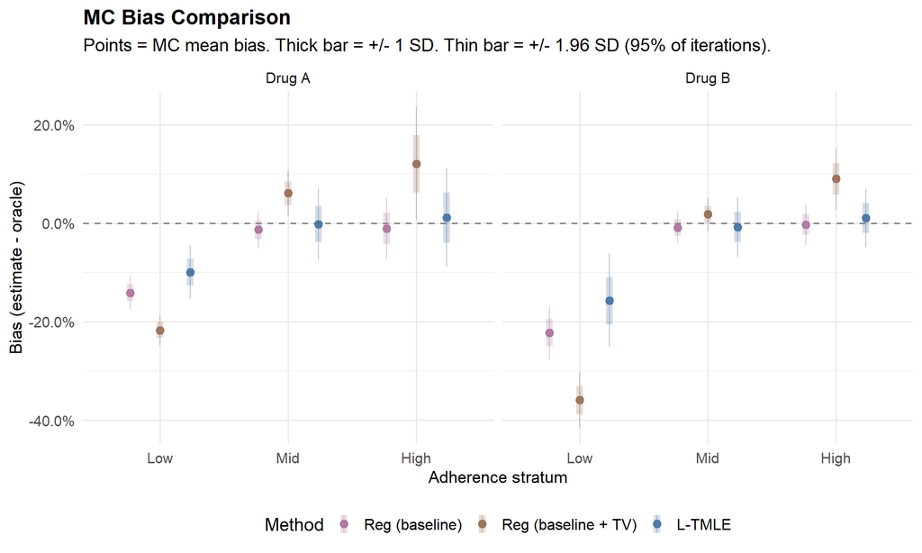

## 10.2 Drug contrast bias: all methods

```
  [saved: fig-mc-bias-rd]
```

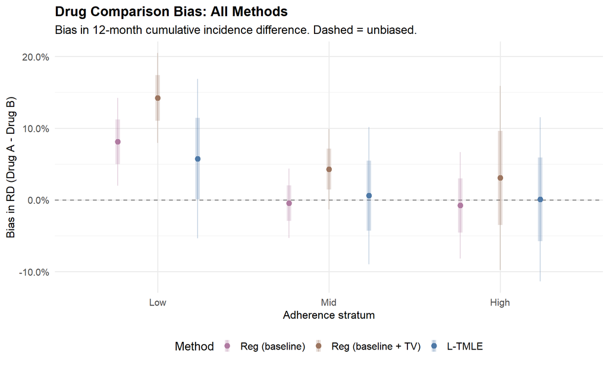

## 10.3 Absolute bias comparison

```
  [saved: fig-mc-abs-bias]
```

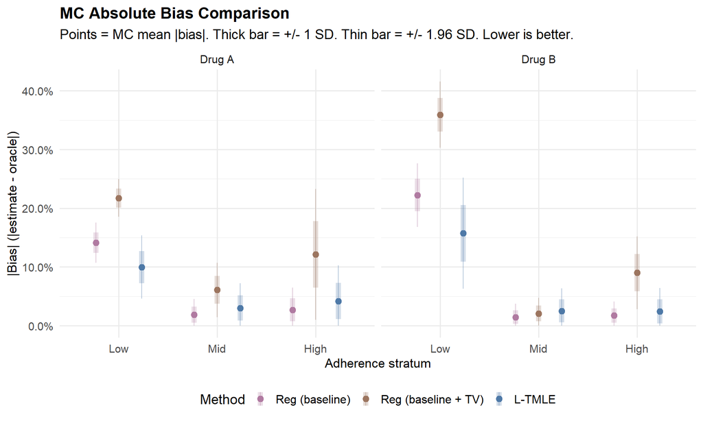

## 10.4 Absolute drug contrast bias: all methods

```
  [saved: fig-mc-abs-bias-rd]
```

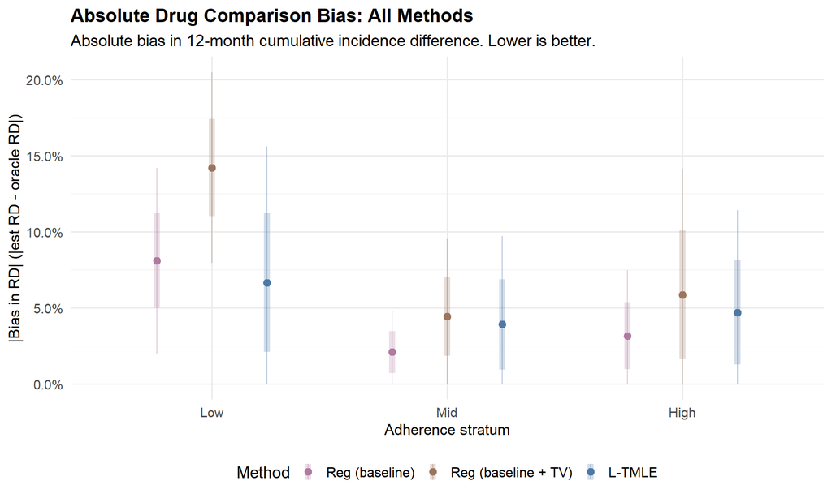

## 10.5 Regression-only bias comparison

```
  [saved: fig-mc-bias-reg]
```

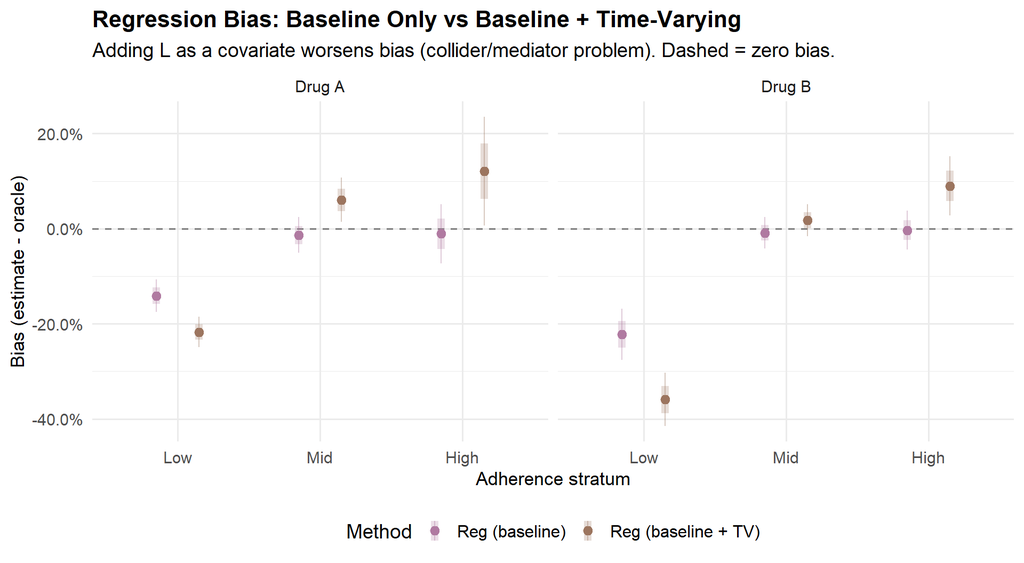

Figure 23: Bias comparison: baseline-only regression vs baseline + time-varying regression. Adjusting for time-varying covariates (L) makes bias WORSE due to collider bias — L is simultaneously a confounder and a mediator.

## 10.6 Drug contrast bias (Risk Difference: Drug A - Drug B)

This figure shows the bias in the **12-month cumulative incidence difference between drugs** (RD = Drug A risk - Drug B risk) within each adherence stratum. The oracle RD is computed from the per-drug oracles. If a method is equally biased for both drugs, the RD bias cancels; if it’s differentially biased (e.g., more confounded for one drug), the RD bias persists.

```
  [saved: fig-mc-bias-reg-rd]
```

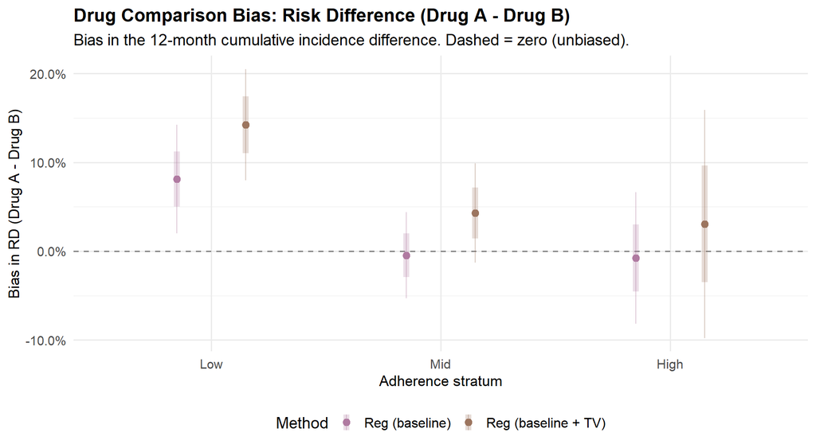

Figure 24: Bias in the drug risk difference (Drug A - Drug B) by adherence stratum. Regression methods show differential bias across drugs, leading to biased drug comparisons — especially in the Low stratum.

# 11 Estimand Diagnostic

This section loads the estimand diagnostic results showing how each method’s implicit oracle (what it is actually estimating) compares to the true L-TMLE oracle.

Table 9: Estimand diagnostic: each method targets a different oracle under strong TV confounding. The gap columns show how far naive/regression oracles are from the true causal estimand (L-TMLE oracle).

| Drug | Stratum | Naive Oracle | Reg(base) Oracle | Reg(TV) Oracle | L-TMLE Oracle | Gap: Naive | Gap: Reg(base) |
| --- | --- | --- | --- | --- | --- | --- | --- |
| Drug A | High | 0.1079 | 0.1180 | 0.2573 | 0.1214 | -0.0135 | -0.0034 |
| Drug A | Low | 0.3877 | 0.3791 | 0.3027 | 0.5208 | -0.1330 | -0.1417 |
| Drug A | Mid | 0.1767 | 0.1817 | 0.2560 | 0.1951 | -0.0184 | -0.0134 |
| Drug B | High | 0.1219 | 0.1297 | 0.2222 | 0.1320 | -0.0101 | -0.0023 |
| Drug B | Low | 0.5381 | 0.5235 | 0.3865 | 0.7408 | -0.2027 | -0.2173 |
| Drug B | Mid | 0.2408 | 0.2418 | 0.2682 | 0.2498 | -0.0090 | -0.0080 |

```
  [saved: fig-estimand-diagnostic]
```

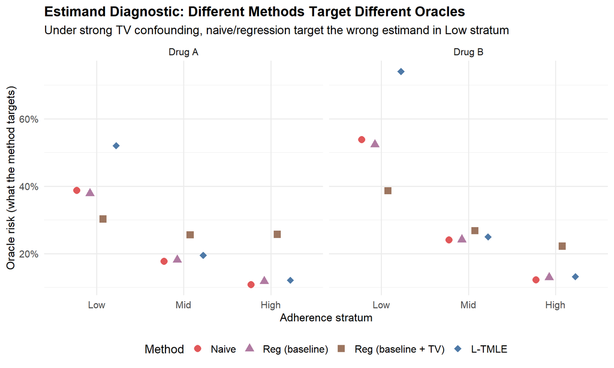

Figure 25: Estimand comparison: what each method is actually estimating vs the true causal oracle. Large gaps for naive/regression in the Low stratum reveal that these methods target fundamentally different (wrong) estimands.

Key finding: Under strong TV confounding, naive and baseline-regression methods target fundamentally different estimands from L-TMLE, particularly in the Low stratum. The gap is largest where the feedback loop is most active: patients with low PDC experience worsening health (via strong betaP), which further depresses their adherence (via strong alphaL), creating a vicious cycle that confounds the naive estimate.

# 12 Summary Takeaways

Table 10: Key takeaways: strong TV confounding amplifies the advantage of L-TMLE

[output not shown]

# 13 Extension: Intercurrent Events

In real-world EHR data, we also face informative censoring, treatment switching, and informative monitoring. These are additional time-varying nodes in the DAG that L-TMLE can handle through the same framework.

```
  [saved: fig-intercurrent-dag]
```

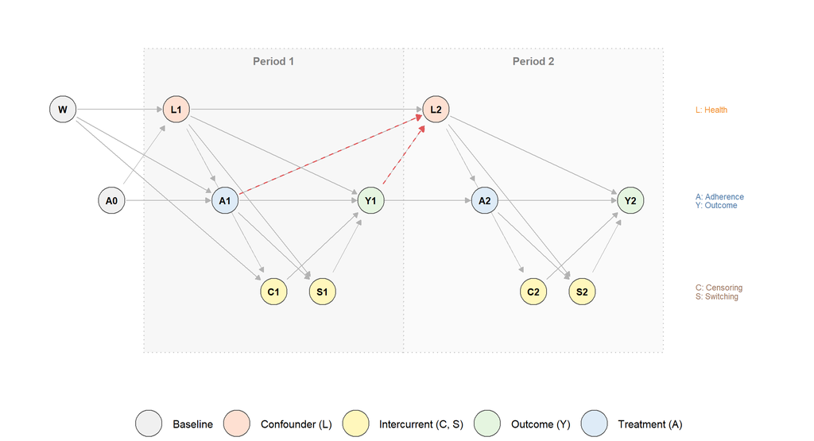

Figure 26: Longitudinal DAG with intercurrent events. At each period: L -> A -> C -> S -> Y. Censoring (C) and switching (S) are driven by health and adherence. Red dashed arrows show feedback from treatment/outcome to future confounders.

### 13.0.1 How L-TMLE handles intercurrent events

| Intercurrent Event | Challenge | L-TMLE Handling |
| --- | --- | --- |
| **Informative censoring (LTFU)** | Patients who drop out are sicker / less adherent | IPCW: weight by inverse probability of remaining uncensored |
| **Informative monitoring** | Sicker patients tested more often — ascertainment bias | Include monitoring as an L-node; adjust in the g-model |
| **Treatment switching** | Patients switch based on failure / side effects | Include switching as treatment node or censor at switch |
| **Competing risks (death)** | Death precludes failure observation | Treat as censoring; estimate cause-specific risk |

The key point: each intercurrent event becomes an additional node in the DAG. L-TMLE handles them all through the same backward iterative targeting — intervene on treatment/adherence, adjust for confounders, weight for censoring. No new methodology is needed, just more nodes.

# 14 Mediation Analysis Framework

How much of the treatment effect operates *through* adherence vs through other pathways? The mediation DAG below shows the decomposition. The **total effect** of Drug (A) on Outcome (Y) can be decomposed into:

- **Natural indirect effect (NIE)**: the part mediated through adherence (A → PDC → Y)
- **Natural direct effect (NDE)**: the part operating through other pathways (pharmacokinetics, resistance barrier, etc.)

In the presence of time-varying confounding, standard mediation (Baron & Kenny, structural equation models) is biased. Longitudinal mediation requires interventional effects or the mediational g-formula.

```
  [saved: fig-mediation-dag]
```

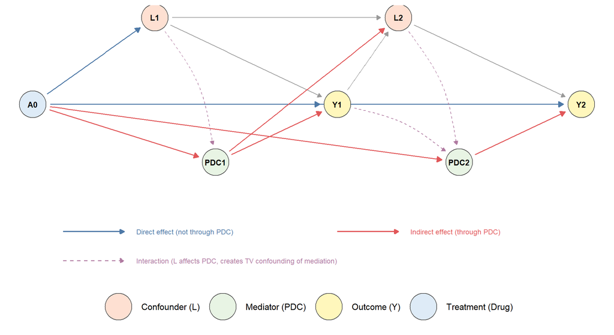

### 14.0.1 What the mediation analysis would estimate

| Estimand | Question | Method |
| --- | --- | --- |
| **Total effect (TE)** | What is the overall effect of Drug A vs B on failure? | LMTP natural risk comparison |
| **Natural direct effect (NDE)** | What is the drug effect if we *fix* adherence at its natural level under Drug B? | Interventional direct effect via longitudinal g-formula |
| **Natural indirect effect (NIE)** | How much of the drug effect operates by changing adherence? | TE - NDE, or interventional indirect effect |
| **Controlled direct effect (CDE)** | What is the drug effect at a *specific fixed* adherence level? | L-TMLE static regime, compare Drug A vs B at same PDC |

The quantile-matching analysis in the previous section provides an informal version of the CDE — it fixes the adherence distribution rather than a single level. A formal mediation decomposition (NDE/NIE) requires additional assumptions (cross-world independence) and is a planned extension.

# 15 Export Figures

All figures rendered during this document are saved to a single `.rds` file. Load in R with `figs <- readRDS("talk_v3_figures.rds")` then access individual plots by name (e.g., `figs$"fig-oracle"`).

```
Saved 27 figure(s) to C:/Users/andre/OneDrive/Documents/hiv_adherence_simulation/simulation V4/manuscript/talk_v3_figures.rds
```

```
Available figures:
```

```
 - fig-dag
 - fig-dag-step1
 - fig-dag-step2
 - fig-dag-step3
 - fig-dag-step4
 - fig-dag-step5
 - fig-dag-step6
 - fig-density-quantile
 - fig-estimand-diagnostic
 - fig-intercurrent-dag
 - fig-lmtp-shift
 - fig-ltmle-fine-70plus
 - fig-ltmle-fine-extended
 - fig-ltmle-vs-oracle-3cat
 - fig-matched-forest
 - fig-mc-abs-bias
 - fig-mc-abs-bias-rd
 - fig-mc-bias
 - fig-mc-bias-rd
 - fig-mc-bias-reg
 - fig-mc-bias-reg-rd
 - fig-mediation-dag
 - fig-naive
 - fig-oracle
 - fig-pdc-violin
 - fig-shift-dist
 - fig-support-heatmap
```